# Snowmelt Seed Analysis RMBL 2019

Loy Xingwen and Berry Brosi

started 18/12/2020, most recent updates 13 May 2022

# 1 Overview

In this analysis, we assess if the timing of snowmelt impacts seed set in montane plant communities, with a plant-community-level focus. We conducted an accelerated snowmelt experiment at RMBL, Colorado in summer 2019. We worked at 8 sites scattered across 2 valleys. In each site, we had paired control and snowmelt acceleration plots, each 14 x 10 m (thus there were 16 plots total). We accelerated snowmelt by solarizing the snow with black shade cloth, which was removed just before snow melted to ground level. Snowmelt rate in control plots was unmanipulated. In many plant species, accelerating snowmelt caused earlier plant flowering relative to controls. We hypothesize that earlier snowmelt date could affect plant seed set through advances in flowering time that potentiate plant-pollinator phenology mismatches.

## 1.1 Package Installation

- This project uses package management via the `renv` library
  - more at https://rstudio.github.io/renv/articles/renv.html
- **for those collaborating on this package**
  - the first time you open / run the project, after any and all background code has been run, call `renv::restore()` in the R console; you only have to do this once
  - anytime you add or remove a package or packages, call `renv::snapshot()` to update the “lockfile” of which packages `renv` is managing; BUT do this only *after* you make sure that all of the packages are playing nicely with one another!!
  - most of the time, that is all you will need to do
  - if you do run into package conflicts / issues, you can call `renv::restore()` to go back to the set of packages and versions that you previously were using
  - for more, see [collaborating with `renv`](https://rstudio.github.io/renv/articles/collaborating.html)

```r
# (note that chunk header is set to not display results / messages / warnings
# otherwise a substantial amount of unhelpful text printed in the report)

# clear environment:
rm(list = ls())

# create a list of needed packages:
# (ADD / delete the packages you need / don't below!)
Packages <- c("tidyverse", "knitr", "kableExtra", "glmmTMB", "fitdistrplus",
              "reshape2", "vegan", "car", "ggpubr", "broom.mixed", "mclogit",
              "DHARMa", "gridExtra", "renv")

# this line loads all of the packages:
lapply(Packages, library, character.only = TRUE)

# suppress redundant messages from dplyr about group-level summarizing:
options(dplyr.summarise.inform = FALSE)

# format package list for printing below:
Packages <- paste(Packages, sep = ", ")

# ==========================
# RENV info

# # SNAPHOT packages for `renv`
# # if using renv, then run the line of code below whenever packages change
# # ...but ONLY after making sure that the code is running and packages are
# # playing nicely with one another
# renv::snapshot() # leave this commented out, run as needed

# # RESTORE packages using `renv`
# # only use this if you have added new packages or changed package versions
# # and your code is now not working
# renv::restore() # leave this commented out, only use if needed (rare)
```

**Packages used:**

tidyverse, knitr, kableExtra, glmmTMB, fitdistrplus, reshape2, vegan, car, ggpubr, broom.mixed, mclogit, DHARMa, gridExtra, renv

# 2 Data

## 2.1 Data import

three datasets to import:

- seed data
  - most of the relevant data are included in here; 1155 rows in the original dataset
- snowmelt data
  - one data point per plot (16 plots, 8 sites each with a control and a snowmelt acceleration plot); data for Julian day on which meltout occurred and acceleration of the snowmelt plot relative to the control
- flowering phenology data
  - one data point per plot-species combination; 116 rows
  - data on how many weeks the flowering phenology in the snowmelt-accelerated plot was advanced relative to the control
  - all control plots have a zero (acceleration is relative to this)

```r
# seed data raw
masterdat = read.csv("data/Masterseed2019.csv", stringsAsFactors = F, header=T)
# snowmelt dates data raw
snowmeltdat = read.csv("data/regressionmeltdays.csv", header = T)
# species-plot level phenological shift
phenoshift = read.csv("data/phenoshifted.csv", stringsAsFactors = F, header=T)

# clean up `Packages` list (doing it here because had to print above):
rm(Packages)
```

## 2.2 Data formatting

The basic plan is to set up the seed data (`masterdat`) as the primary dataset used, and to merge the snowmelt and phenology data into the seed data frame. A fair amount of miscellaneous data cleaning and formatting has to be conducted first.

### 2.2.1 miscellaneous data formatting

among other things:

- change experimental state from “manip” (i.e. manipulated) to “accel” (i.e. snowmelt accelerated) for clarity throughout
- set up species name abbreviations
- assignment of columns as factors
- renaming “treat” column to “plant.treat”
- creating a self-compatibility column
- removing rows without flower number
- change site name from “Pfieler” (incorrect) to “Pfeiler” (correct)
- prepping data for merges (creating ID columns aggregated at various levels)

```r
# ===============
# site name ("Pfieler" to "Pfeiler")

# masterdat
masterdat$site = str_replace(masterdat$site, "Pfieler", "Pfeiler")
# snowmeltdat
snowmeltdat$site = str_replace(snowmeltdat$site, "Pfieler", "Pfeiler")
# phenoshift
phenoshift$site.plot.sp = str_replace(phenoshift$site.plot.sp, "Pfieler", "Pfeiler")

# ===============
# experimental state ("manip" to "accel")

# masterdat
masterdat$plot.treat = str_replace(masterdat$plot.treat, "manip", "accel")
# snowmeltdat
snowmeltdat$plot.treat = str_replace(snowmeltdat$plot.treat, "manip", "accel")
# phenoshift
phenoshift$site.plot.sp = str_replace(phenoshift$site.plot.sp, "manip", "accel")

# ===============
# species names

# abbreviate species names - M. fusiformis
masterdat$g.species = paste(substr(masterdat$species, 1, 1), sub("^[^ ]*", ".", masterdat$species), sep = "")

# abbreviate species names - Genus only
masterdat$genus = gsub( " .*$", "", masterdat$species)

# abbreviate species names - first two letters of genus and species
masterdat$ge.sp = paste(substr(masterdat$species, 1, 2), substr(sub("^\\S+\\s+", '', masterdat$species), 1, 2), sep = "")

# ===============
# seed data

# Change NAs to 0; we have removed cases where both columns say NA, which is when we lost a plant.
masterdat$dev.seed1[is.na(masterdat$dev.seed1)] <- 0
masterdat$dev.seed[is.na(masterdat$dev.seed)] <- 0

# create column for total seed counts
masterdat$totalseeds = masterdat$dev.seed1 + masterdat$dev.seed

# ===============
# miscellaneous cleanup and formatting

# rename the full `species` column
names(masterdat)[names(masterdat) == "species"] <- "full.species"

# rename the ge.sp column to simply 'species'
names(masterdat)[names(masterdat) == "ge.sp"] <- "species"

# remove exclusion treatment plants
masterdat = subset(masterdat, masterdat$treat != "exclusion")

# factors
masterdat$site = factor(masterdat$site)
masterdat$plot.treat = factor(masterdat$plot.treat)
masterdat$species = factor(masterdat$species)

# variables to factors
masterdat$site = factor(masterdat$site)
masterdat$plot.treat = factor(masterdat$plot.treat)
masterdat$species = factor(masterdat$species)

# rename hand pollination treatment variable
# to disambiguate it from the plot treatment variable
names(masterdat)[names(masterdat) == "treat"] <- "plant.treat"

# create column of whether plant species is self compatible or not
masterdat$selfer = 'F'
masterdat$selfer[masterdat$species == "Thfe"] = 'T'
masterdat$selfer[masterdat$species == "Bost"] = 'T'
masterdat$selfer[masterdat$species == "Taof"] = 'T'
masterdat$selfer[masterdat$species == "Rain"] = 'T'

# log transform the seed set for future plotting
masterdat$logseed = log(masterdat$totalseeds + 1)

# ===============
# prep for merging

# unique ID for each plot
masterdat$plotID = paste(masterdat$site.abbrev, masterdat$plot.orient, sep=".")

# ID for individual plants
masterdat$plantID = paste(masterdat$site, masterdat$plot.treat, masterdat$species, masterdat$quad, masterdat$grid, masterdat$plant.treat, sep = ".")
```

### 2.2.2 merge seed and meltout data

for this merge, we need to create a unique ID for both `masterdat` and `snowmeltdat` that includes both the site and the plot within the site (snowmelt acceleration vs. control). We don’t drop the snowmelt dataframe after the merge, as we use it down the road in plotting overall snowmelt trends.

```r
# create unique ID in snowmelt data
snowmeltdat$meltID = paste(snowmeltdat$site, snowmeltdat$plot.treat, sep = ".")

# create unique ID for snowmelt in seed data
masterdat$meltID = paste(masterdat$site, masterdat$plot.treat, sep = ".")

# drop extra columns in snowmelt data
drops <- c("site","plot.treat")
snowmelttemp = snowmeltdat[ , !(names(snowmeltdat) %in% drops)]

# merge
masterdat <- merge(masterdat, snowmelttemp, by="meltID")

# cleanup
rm(drops, snowmelttemp)
```

### 2.2.3 merge phenology data into seed data

Similar to the above, we create an individual ID for `masterdat` for species within plots within sites (this already exists for the `phenoshift` data). Once we have merged the phenology data into the seed data, we remove that dataframe for clarity and workspace cleanliness as it is not used downstream.

```r
# create ID for plots
masterdat$site.plot = paste(masterdat$site, masterdat$plot.treat, sep=".")

# create unique identifier for species-plot
masterdat$site.plot.sp = paste(masterdat$site, masterdat$plot.treat, masterdat$species, sep=".")

# merge species-plot phenological shift data with seed data
masterdat = left_join(masterdat, phenoshift, by = "site.plot.sp")

# set up binary phenological shift variable, 'phenshift.binary':
masterdat$phenshift.binary="no"
masterdat$phenshift.binary[masterdat$phenshift>0]="yes"

# cleanup (`phenoshift` data not subsequently used)
rm(phenoshift)
```

### 2.2.4 post-merge formatting

dropping extraneous columns from `masterdat`; converting phenology shift to negative (since it is earlier relative to controls)

```r
# select only needed columns
myvars = c("site", "site.abbrev", "plot.treat", "site.plot", "species",
          "full.species", "plant.treat", "num.flowers", "totalseeds",
          "phenshift", "phenshift.binary")

masterdat = masterdat[myvars]
rm(myvars) # cleanup

# make phenological shift data negative
# (earlier relative to control)
masterdat$phenshift = masterdat$phenshift*(-1)
```

# 3 Analysis

there are three primary classes of analyses, all at a community level:

- overall fecundity
  - assesses how phenological shifts (driven by our experimental snowmelt acceleration) impact overall seed production
- pollen limitation
  - assesses the extent to which changes in fecundity were driven by pollen limitation (as opposed to resource limitation)
- relative proportions of seed output
  - even if community-level fecundity changes, we want to know the potential for reshaping plant communities; this analysis assesses if the relative proportions of seed produced change in control vs. snowmelt acceleration plots (in the same site)

in terms of workspace / environment management, this analysis is set up for cleanliness. Ultimately maintaining the one master data file (`masterdat`) and one subsetted data file for each of the three classes of analysis. Other objects (models, plots, variables) are maintained only as long as necessary.

## 3.1 Preliminaries

Analysis preliminaries include:

- simple calculations that give an overview of the data
- basic probability distribution choice for the seed data
- plot of efficacy of snowmelt manipulations
- plot of overall phenological shift by site

### 3.1.1 Data overview

```r
# most of this is just displayed in the text below

# Number of plants
# * `r nrow(masterdat)` plants

# Number of plants per treatment
plants.per.treat = masterdat %>% group_by(plot.treat) %>%
  summarise(no_rows = length(plot.treat))
    # + `r as.numeric(plants.per.treat[2,2])` plants in control plots
    # + `r as.numeric(plants.per.treat[1,2])` plants in snowmelt-accelerated plots

# Total number of seeds
# * `r as.integer(sum(masterdat$totalseeds))` total seeds
# "as.integer" makes it so that it does not display in scientific notation
```

Overall, we measured:

- 1092 plants
  - 545 plants in control plots
  - 547 plants in snowmelt-accelerated plots
- 96118 total seeds

These totals come after substantial data cleaning and as such do not include bagged plants, etc. At the same time, however, for subsequent analyses these data are further reduced, for example excluding hand-pollinated plants in all but the pollen limitation analyses, plant species that did not occur in at least three sites, etc.

### 3.1.2 Distribution choice for seed data

Before we fit any models, we want to see how the response variable (seed count) is distributed. It is a discrete count variable; in past data analyses, seed counts have been overdispersed and fit much better with a negative binomial distribution than with a Poisson, but worth a quick check. Not worth saving the graphs, include in this report but not in publication.

In the plot below, **Poisson is on the left** and **Neg Binomial is on the right**, and the distributions are also named in the plot legends (couldn’t find an easy way to include a title with `plotfitdist`).

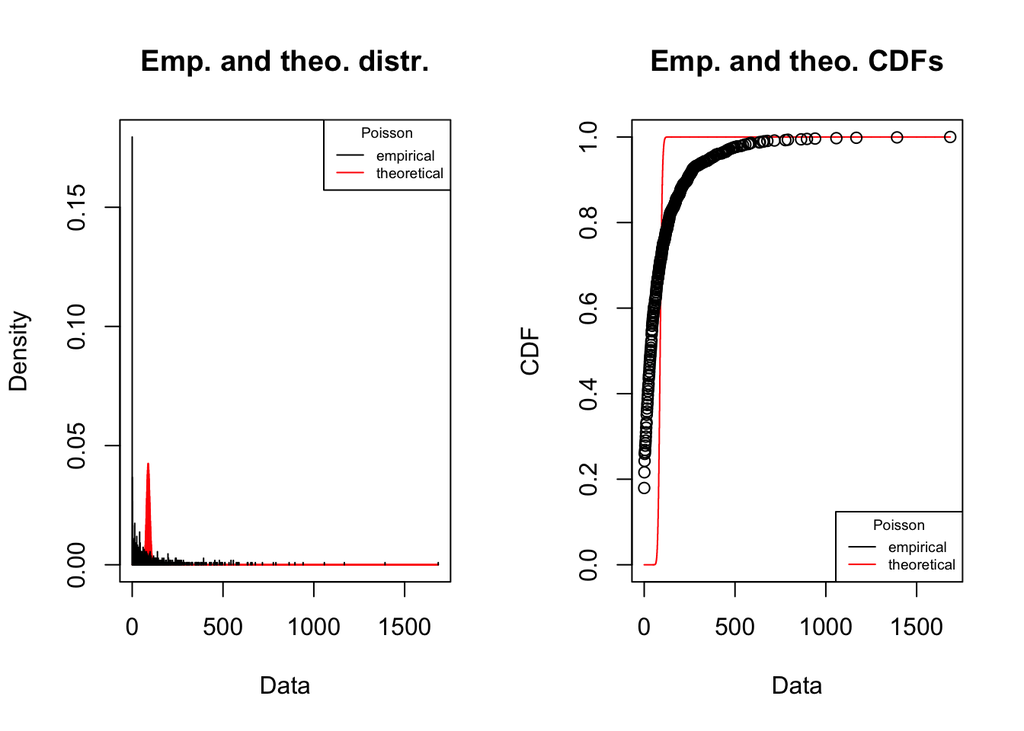

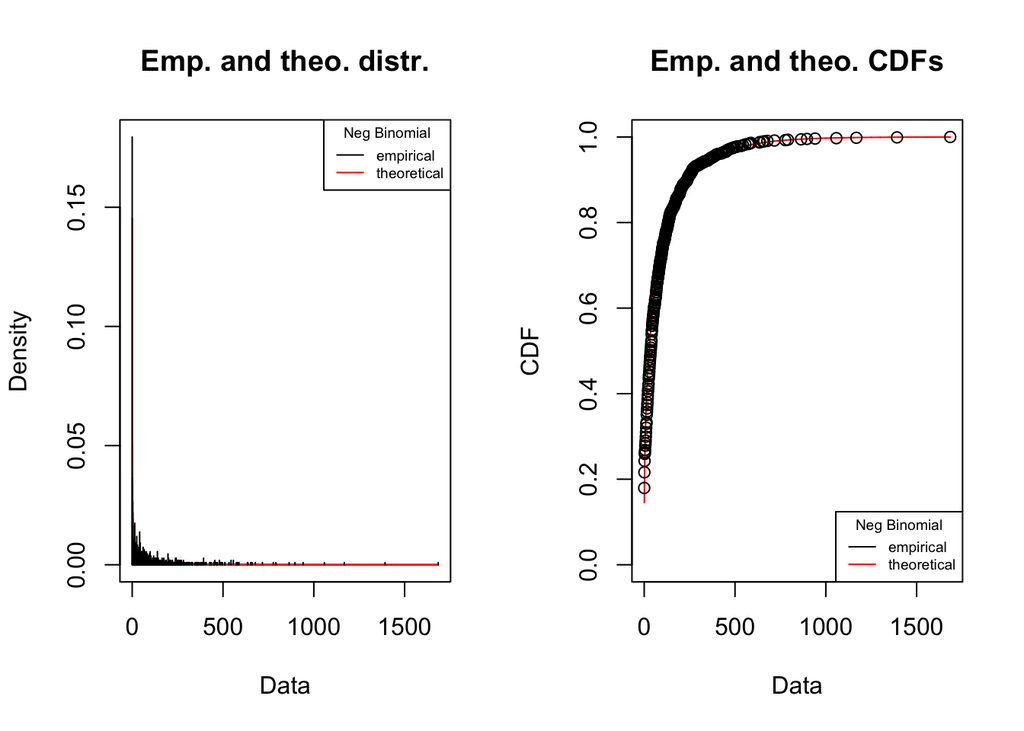

```r
# assess distribution of the response variable
isitgonnabepois <- fitdist(masterdat$totalseeds,"pois")
isitgonnabenbinom <- fitdist(masterdat$totalseeds,"nbinom")

# plot them:
# note: the side-by-side display of the plots specified in chunk header
plot(isitgonnabepois, title = "Poisson")
plot(isitgonnabenbinom, title = "Neg Binomial")

# cleanup, including `plants.per.treat` from previous code chunk
rm(isitgonnabenbinom, isitgonnabepois, plants.per.treat)
```

The seed data generally fit a negative binomial distribution much better than a Poisson (no surprise). We also separately assess model assumptions (residuals, overdispersion, zero-inflation) after each statistical modeling section.

### 3.1.3 Plots of overall snowmelt and phenology

#### 3.1.3.1 Snowmelt plot

Here’s a plot of the Julian days that the snowmelt-accelerated plots melted out, with sites sorted by snowmelt day in the control plots:

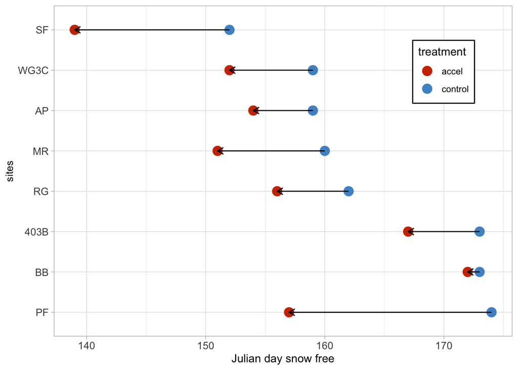

#### 3.1.3.2 Phenology plot

While it would seem natural to use the `phenoshift` dataset here, which is already aggregated by site, plot, and species (not `masterdat`), the issue is that some of the species in `phenoshift` were assessed for phenology but did not ultimately have fecundity measured (either at all, or within some of the plots). At the same time, post-merge the phenology data are pseudoreplicated in `masterdat` (i.e. recorded on each line, but actually only measured at the species-by-plot level). To get rid of the pseudoreplication issue, conduct a two-stage summarization of the `masterdat` data. First, calculate the per-species, per-site mean phenology shift; for any given species, the numbers are all the same (again because they were filled in by the merge). Second, once the data have been aggregated to the site-by-species level, *then* take the mean again to calculate the true per-site mean; at this point we can also calculate standard deviations and thus confidence intervals.

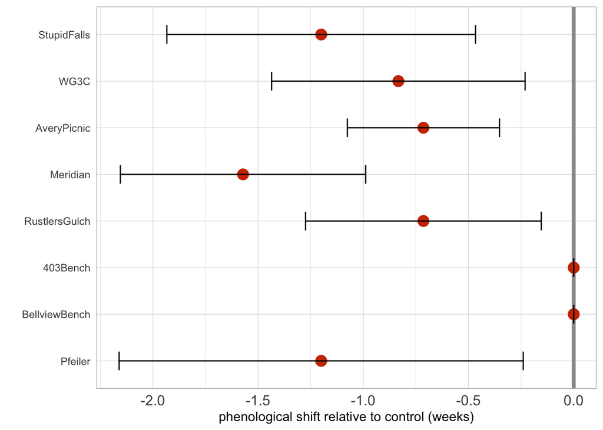

```r
# first aggregation (get rid of pseudoreplication)
meansbysite = masterdat %>% filter(plot.treat == "accel") %>%
  group_by(site, species) %>% summarise(speciesmean = mean(phenshift,
                                                           na.rm = T))

# get rid of NAs (2 site-by-species combos only have NAs)
meansbysite = meansbysite %>% filter(!(is.na(speciesmean)))

# second aggregation (actually calculate by-site means)
meansbysite = meansbysite %>% group_by(site) %>%
  summarize(mean = mean(speciesmean), std = sd(speciesmean), n = n()) %>%
    mutate(upper = mean + 1.96*(std/sqrt(n)), lower = mean - 1.96*(std/sqrt(n)))

# relevel in melt-out order:
meansbysite$site <- factor(meansbysite$site, levels = c("Pfeiler",
                    "BellviewBench", "403Bench", "RustlersGulch", "Meridian",
                    "AveryPicnic", "WG3C", "StupidFalls"))

# plot
meanplotbysite <- ggplot(meansbysite, aes(x=mean, y=site)) +
      geom_vline(xintercept = 0,  color = "gray60", size = 1.5) +
  geom_point(size = 4, shape = 19, color = "orangered3") +
  geom_errorbarh(aes(xmin = lower, xmax = upper), height = .4) +
  ylab("") +
  xlab("phenological shift relative to control (weeks)") +
  theme_light() +
  theme(axis.text.x = element_text(size = 12)) +
  theme(axis.ticks = element_blank())

# display plot
meanplotbysite
```

```r
# note: don't remove plot object until merged with previous plot
```

#### 3.1.3.3 Combine snow and phenology plots

Combined plot not shown in this report but is saved for publication. Before combining the plots, remove the *y*-axis labels (sites) from the phenology plot since they are the same as for the snowmelt plot, to save space.

```r
# get rid of y-axis labels in phenology data
# in preparation for merging with snowmelt plot:
meanplotbysite = meanplotbysite + theme(axis.text.y = element_blank())

# combine with snowmelt plot
# (chunk header has code that prevents it from being displayed)
meltphenplot = grid.arrange(plotsnow, meanplotbysite, nrow = 1)
```

```r
# # SAVE PLOT: (keep this commented out to prevent repeated saving on GitHub)
# # re-save when this changes, but only as needed
# ggsave(meltphenplot, file = "plots/meltphenplot.pdf", width = 9, height = 3)
# ggsave(meltphenplot, file = "plots/meltphenplot.jpg", width = 9, height = 3)

# cleanup
# includes removing `phenoshift` dataset, not used again
rm(plotsnow, meanplotbysite, meansbysite, meltphenplot)
```

## 3.2 Community Fecundity

The idea here is to see how accelerating flowering phenology impacts plant fecundity across the community. Thus, we are including all species into a single model. We are using **whole-plant fecundity** as a response variable, since phenological shifts could have led to differences in resource availability that could have shifted the total number of flowers and/or ovules within flowers.

The key explanatory variable is `phenshift.binary`, or whether or not a plant accelerated its flowering in response to our manipulations. Thus, we are including data for cases in which there was accelerated flowering, to assess whether or not those impacted (whole-plant) fecundity. The models are set up to assess not just overall impacts but to also inform us if different species react differently to the manipulation, which is also key at the community level. Thus, the models include plant species and number of flowers as explanatory variables.

Our philosophical approach to the models:

- ultimately we have a complex statistical model and really don’t have that many degrees of freedom to play with (6 sites at which plants accelerated blooming relative to controls)
  - initial attempts at something close to a full model—with all possible interactions between the three explanatory variables—did not converge, which is unsurprising given the degrees of freedom and the substantial variation in the data
- focus on the *simplest possible model that gets at what we want to understand*, despite the complexity
  - we know that phenological shifts are going to have different effects on different species; so there has to be an interaction there (`phenshift.binary` $\times$ `species`)
  - we know that flower number matters for seed count, and that the relationship between flower number and seed count is different for different species (so also have to have a `species` $\times$ `num.flower` interaction)
  - BUT ultimately in our model we don’t want to waste degrees of freedom assessing the main effects of species (of course species have different seed counts) or flower number (of course more flowers means more seeds)—we would want to include if we had a ton of data, but these would be the first to go if model doesn’t converge
  - if we can assess a main effect of phenological shift, that would be ideal
  - approach: start with the absolute simplest model that gets at what we want—a model including *only* the three-way interaction (`phenshift.binary:species:num.flowers`)
  - if this converges, subsequently add the main effect of phenological shift (this would tell us if there is an overall effect of phenological shift on seed production)
  - if that works, then also include a two-way interaction between phenological shift and plant species (this would inform us specifically that different species respond differently to phenological acceleration, irrespective of flower number)

### 3.2.1 data prep community fecundity

- use phenology shift yes/no (`phenshift.binary`) as the explanatory variable
  - `phenshift` (continuous) is a problematic predictor… temporal coarseness (weekly assessment) means that values range from just 0 to 3
  - moreover, low # of observations at larger phenological shifts (2 and 3 weeks)
  - e.g., 449 observations with a phenshift of 0; but only 15 observations for phenshift = 3 and 45 for phenshift = 2
  - in addition, yes/no is easier to fit statistically than a line among four points, wihch is important for these complex models in which convergence could be an issue
- for improved model convergence, drop species for which there are observations at fewer than 3 sites
  - especially Hyca and Getr: only one site, and for Hyca no phenological shift
  - but also Frvi, Vipr, and Thfe, each only present in two sites
  - **dropping these species led to model convergence, in models that didn’t converge previously**
- also checked to see if there were species for which there was no binary phenological shift in any site:
  - there are (Hyca and Thfe), but these were already removed in the step above
- drop any sites as necessary that no longer have species representation following the above
  - BellviewBench and 403Bench: no species were phenologically accelerated
- finally, to be able to make comparisons at the community level, want to only include site-species pairs in which we have both phenologically accelerated plants (in the snowmelt manipulation plot) and unaccelerated plants (in the control plots) in the same sites

```r
# subset data to those relevant for the community-level analyses
# "reddat" = "reduced data"; includes all data (including hand-pollinated),
# then do "commfecdat" = "community fecundity data" for the data used for this
# analysis, specifically **not including hand-pollinated flowers**
reddat = masterdat

# remove species present at fewer than three sites
spp.list = c("Getr", "Hyca", "Frvi", "Thfe", "Vipr")
reddat = reddat %>% filter(!(species %in% spp.list))

# following the above, we also need to drop 2 sites, BBB and 403,
# because none of the species there responded to the snowmelt treatment
# one way to show this is:
# table(reddat$site, reddat$phenshift.binary)
site.list = c("BellviewBench", "403Bench")
reddat = reddat %>% filter(!(site %in% site.list))

# relevel factors to exclude missing species and sites
reddat$species = factor(reddat$species)
reddat$site = factor(reddat$site)

# before site-species combo limitation, save a version of these data
# to use in the seed proportion analysis:
seedpropdat = reddat

# remove rows that have no 'number of flowers'
# we want to keep those data for `seedpropdat` (saved in the line above);
# but our models for community fecundity and pollen limitation include flower num
# so need to remove those rows for analyses of community fecundity & poll limit:
reddat = reddat %>% filter(!(is.na(num.flowers)))

# limit site-species combos to only those that have
# a phenological shift; that would focus the data on only where we have the
# appropriate contrasts. Also limit to site-species combos where there are at
# least 5 plants in both phenology-accelerated and not (control)

# Find these by comparing these tables:
# table(reddat$site, reddat$phenshift.binary, reddat$species)

# Bost @ RustlersGulch
# Denu @ Pfeiler, RustlersGulch
# Lala @ AveryPicnic
# Mefu @ WG3C
# Popu @ WG3C (due to sample sizes of 2 and 5 plants)
# Rain @ WG3C
# Taof @ StupidFalls

reddat = reddat %>% filter(!(species=="Bost" & site == "RustlersGulch"))
reddat = reddat %>% filter(!(species=="Denu" & site == "Pfeiler"))
reddat = reddat %>% filter(!(species=="Denu" & site == "RustlersGulch"))
reddat = reddat %>% filter(!(species=="Lala" & site == "AveryPicnic"))
reddat = reddat %>% filter(!(species=="Mefu" & site == "WG3C"))
reddat = reddat %>% filter(!(species=="Popu" & site == "WG3C"))
reddat = reddat %>% filter(!(species=="Rain" & site == "WG3C"))
reddat = reddat %>% filter(!(species=="Taof" & site == "StupidFalls"))

# cleanup
rm(spp.list, site.list)

# Data without hand-pollinated plants ("commfecdat")
commfecdat = subset(reddat, reddat$plant.treat != "open-hand")
```

### 3.2.2 models community fecundity

Included in the model random effects specification: there are plots (control vs. manip) nested within each site; add these in as a random effect (random intercept), nested within site: `(1|site/site.plot)`

After model assessment using `DHARMA`, initial models showed significant zero-inflation (i.e. more plants with zero seeds than expected with the fitted negative binomial distribution), but no other issues. The updated models below include a zero-inflation term and do not show any particular issues in terms of model assumptions; see next section (“model assessment”) for more detail.

We display here only the final model, with the 3-way interaction; main effect of phenological shift; and a two-way interaction between phenological shift and plant species).

```r
# shown here from simplest to most complex. We report on the most complex
# of the three in the paper.

# model with *just* the 3-way interaction:
comm.fec = glmmTMB(totalseeds ~ phenshift.binary:species:num.flowers + (1|site/site.plot), family = nbinom2, ziformula = ~1, data = commfecdat)
# cat("Model with 3-way interaction only:\n")
# Anova(comm.fec)
rm(comm.fec) #cleanup

# model with the 3-way interaction plus the main effect of phenshift:
comm.fec.2 = glmmTMB(totalseeds ~ phenshift.binary/species:num.flowers + (1|site/site.plot), family = nbinom2, ziformula = ~1, data = commfecdat)
# cat("Model with 3-way interaction plus the main effect of phenshift:\n")
# Anova(comm.fec.2)
rm(comm.fec.2) #cleanup

# model with main effect of phenshift, 2-way interaction between phenshift and species, and 3-way interaction
comm.fec.3 = glmmTMB(totalseeds ~ phenshift.binary/species/num.flowers + (1|site/site.plot), family = nbinom2, ziformula = ~1, data = commfecdat)
cat("Model with main effect of phenshift, 2-way int b/t phenshift and species, and 3-way int:\n")
```

```
## Model with main effect of phenshift, 2-way int b/t phenshift and species, and 3-way int:
```

```r
Anova(comm.fec.3)
```

```
## Analysis of Deviance Table (Type II Wald chisquare tests)
##
## Response: totalseeds
##                                         Chisq Df Pr(>Chisq)
## phenshift.binary                       36.769  1  1.330e-09 ***
## phenshift.binary:species             1021.585 14  < 2.2e-16 ***
## phenshift.binary:species:num.flowers   75.001 16  1.307e-09 ***
## ---
## Signif. codes:  0 '***' 0.001 '**' 0.01 '*' 0.05 '.' 0.1 ' ' 1
```

```r
# don't cleanup / remove this model just yet; need to do model validation
# and also save model output

## use `broom.mixed` package to save model summary as a table
aov.comm.fec = Anova(comm.fec.3)
out.aov.comm.fec = tidy(aov.comm.fec)
write.csv(out.aov.comm.fec, file = "results/community-fecundity-model-results.csv")

# cleanup
# don't cleanup `comm.fec.3` since we need to model validation
rm(aov.comm.fec, out.aov.comm.fec)
```

- all three effects highly significant:
- main effect of `phenshift.binary`:
  - plot (below) shows that this main effect is negative (less overall seed production in phenologically accelerated vs. control)
- two-way interaction between phenological acceleration and species:
  - indicates that different species respond differently to phenological acceleration
- three-way interaction between phenological acceleration, species, and flower number:
  - indicates that not only do different species respond differently to phenological acceleration overall, but also that they have different responses vis-a-vis flower number (in terms of how phenological acceleration changes the slope of the {flower number} - to - {whole plant fecundity} relationship
- following initial modeling plan, we report on the most complex of these models

#### 3.2.2.1 model assessment community fecundity

Assess model residuals to see if the model meets basic statistical assumptions, using the `DHARMa` package

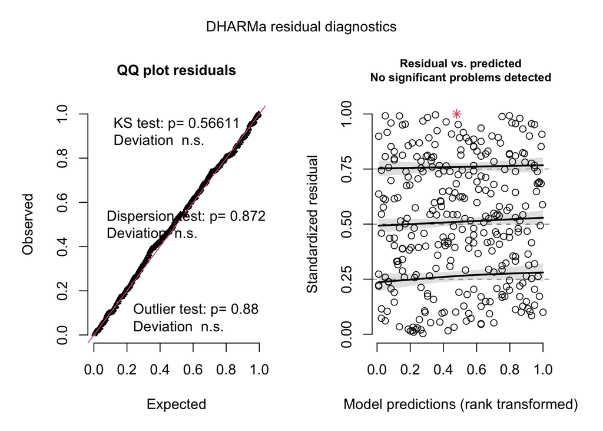

```r
# simulate residuals using DHARMa
# "simoutcommfec" = simulation output, community fecundity models
simoutcommfec <- simulateResiduals(fittedModel = comm.fec.3, plot = F)
plot(simoutcommfec)
```

```r
testDispersion(simoutcommfec, plot = F)
```

```
##
##  DHARMa nonparametric dispersion test via sd of residuals fitted vs.
##  simulated
##
## data:  simulationOutput
## dispersion = 0.8519, p-value = 0.872
## alternative hypothesis: two.sided
```

```r
testZeroInflation(simoutcommfec, plot = F)
```

```
##
##  DHARMa zero-inflation test via comparison to expected zeros with
##  simulation under H0 = fitted model
##
## data:  simulationOutput
## ratioObsSim = 1.0407, p-value = 0.784
## alternative hypothesis: two.sided
```

```r
# cleanup
rm(simoutcommfec, comm.fec.3)
```

Looks great! No noticeable issues with distribution of residuals, heteroscedasticity, dispersion, or zero-inflation. Carry on.

### 3.2.3 plots of community-wide fecundity

#### 3.2.3.1 plot main effect of phenology shift on fecundity

First, aggregate data to mean per-plant fecundity in each of phenologically accelerated and control plants. We have narrowed the data down to plant species - site combinations in which the plants in the snowmelt acceleration plots were actually phenologically accelerated relative to the controls, and for which there were at least 5 individuals for which fecundity was measured in both control and phenologically accelerated groups.

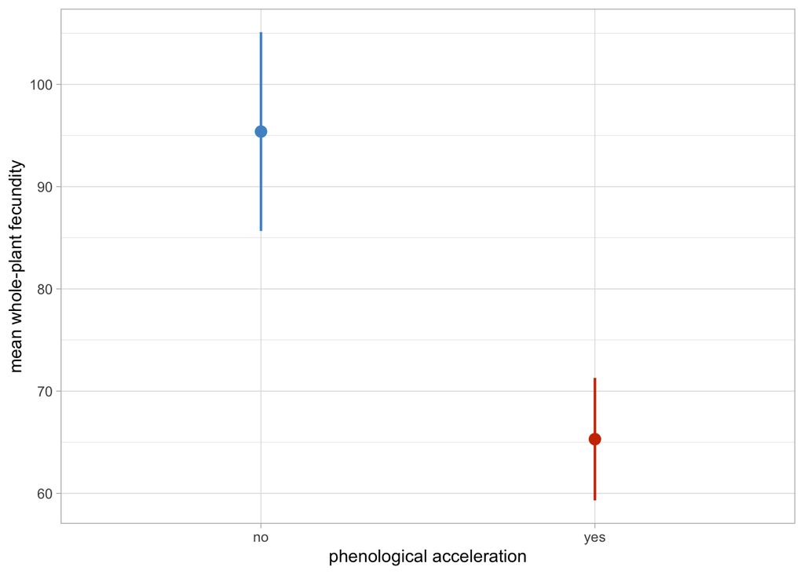

```r
phenfecsum = reddat %>% group_by(phenshift.binary) %>%
  summarise(mean.seeds = mean(totalseeds), sd.seeds = sd(totalseeds,
                                na.rm = T), n.plants = n()) %>%
  # # log version
  # summarise(mean.seeds = log(mean(totalseeds)), sd.seeds = log(sd(totalseeds,
  #                               na.rm = T)), n.plants = n()) %>%
        mutate(ci.upper = mean.seeds + 1.96*(sd.seeds/sqrt(n.plants)),
          ci.lower = mean.seeds - 1.96*(sd.seeds/sqrt(n.plants)),
          se.lower = mean.seeds - sd.seeds/sqrt(n.plants),
          se.upper = mean.seeds + sd.seeds/sqrt(n.plants))

phenfecplot = ggplot(phenfecsum, aes(x = phenshift.binary, y = mean.seeds, color = phenshift.binary)) +
  geom_point(size = 3) +
  # CIs commented out; use SEs instead
  # geom_errorbar(aes(ymin = ci.lower, ymax = ci.upper), width = 0.1)
  geom_linerange(aes(ymin = se.lower, ymax = se.upper), size = 0.75) +
  scale_colour_manual(values=c("steelblue3", "orangered3")) +
  xlab("phenological acceleration") +
  ylab("mean whole-plant fecundity") +
  # # log version
  # ylab("log(mean whole-plant fecundity)") +
  theme_light() +
  theme(legend.position = "none")

phenfecplot # display in Rmarkdown report
```

```r
# # save plot
# # (keep this commented out to prevent repeated saving on GitHub)
# # re-save when this changes, but only as needed
# ggsave(phenfecplot, file = "plots/aggregated-fecundity-by-phenology.pdf",
#   width = 2.5, height = 3)
# ggsave(phenfecplot, file = "plots/aggregated-fecundity-by-phenology.jpg",
#   width = 2.5, height = 3)

# don't cleanup just yet, need to combine plots first
```

Indicates that there is an *overall reduction in fecundity* across the community in plants phenologically shifted vs. not, i.e. a **negative directional impact of phenological acceleration** on whole-plant fecundity.

Note: as in any mixed-effects model, the lack of overlap in confidence intervals cannot be interpreted to mean lack of statistical significance, because of variation in random effects. For example, sites likely have different whole-plant fecundity means if they vary in soil moisture, soil nutrients, shading, etc.; and that variation can be of similar magnitude or greater than the effect size of the main effects.

#### 3.2.3.2 plot fecundity by species

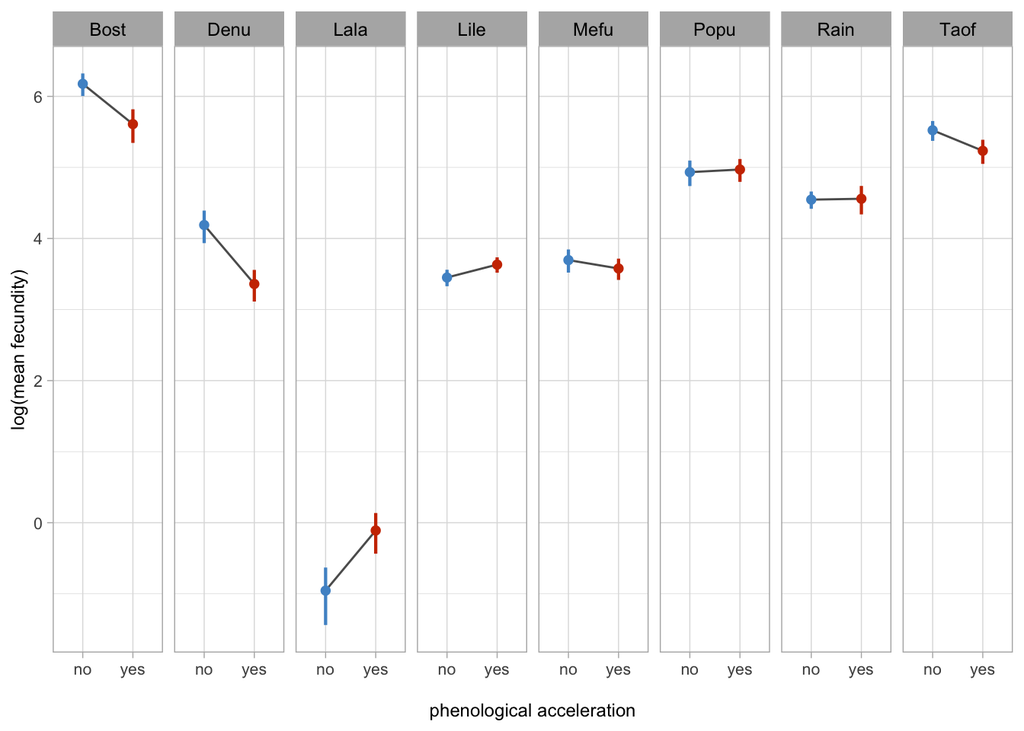

```r
# first, summarize the data
sumsppfec = commfecdat %>%
  group_by(species, phenshift.binary) %>%
  summarise(meanfecund = mean(totalseeds, na.rm = TRUE),
            sdfecund = sd(totalseeds, na.rm = TRUE),
            nfecund = n()) %>%
  mutate(sefecund = sdfecund / sqrt(nfecund),
         # here the `qt` argument is quartiles of the t-distribution;
         # this is more conservative than using a Gaussian / z-dist
         # e.g., in lowest sample size (14), it is 2.16 rather than 1.96
         lower.ci.fecund = meanfecund - qt(1 - (0.05 / 2), nfecund - 1) * sefecund,
         upper.ci.fecund = meanfecund + qt(1 - (0.05 / 2), nfecund - 1) * sefecund,
         lower.se.fecund = meanfecund - sefecund,
         upper.se.fecund = meanfecund + sefecund)

# plot without confidence intervals:
sppfecplot = ggplot(sumsppfec, aes(x=phenshift.binary, y=log(meanfecund), color = phenshift.binary)) +
  geom_line(aes(group = species), color = "grey36", arrow = arrow(angle = 30,
      length = unit(0.07, "inches"), ends = "last", type = "open")) +
  geom_point(size = 1.7) +
  scale_colour_manual(values=c("steelblue3", "orangered3")) +
  facet_wrap(~species, nrow = 1) +
  ylab("log(mean fecundity)") +
  xlab("\nphenological shift (no = control, yes = accelerated)") +
  ggtitle("Phenology shift effects on fecundity by species") +
  theme_light() +
  theme(axis.title.y = element_text(size = 9)) +
  theme(axis.title.x = element_text(size = 9)) +
  theme(axis.text = element_text(size = 8)) +
  theme(strip.text.x = element_text(size = 9, colour = "black")) +
  theme(legend.position = "none")

# # display plot
# # (commented out for this report)
# sppfecplot

# plot with confidence intervals:
sppfecplotci = ggplot(sumsppfec, aes(x=phenshift.binary, y=log(meanfecund), color = phenshift.binary)) +
  geom_line(aes(group = species), color = "grey36") +
  # , arrow = arrow(angle = 30, length = unit(0.07, "inches"), ends = "last", type = "open")) +
  geom_point(size = 1.7) +
  scale_colour_manual(values = c("steelblue3", "orangered3")) +
  geom_linerange(aes(ymin = log(lower.se.fecund), ymax = log(upper.se.fecund)),
                size = 0.75) +
  facet_wrap(~species, nrow = 1) +
  ylab("log(mean fecundity)") +
  xlab("\nphenological acceleration") +
  # ggtitle("Phenology shift effects on fecundity by species") +
  theme_light() +
  theme(axis.title.y = element_text(size = 9)) +
  theme(axis.title.x = element_text(size = 9)) +
  theme(axis.text = element_text(size = 8)) +
  theme(strip.text.x = element_text(size = 9, colour = "black")) +
  theme(legend.position = "none")

# # display plot with CIs
sppfecplotci
```

```r
# # SAVE PLOT
# # =============================
# # for now, the one without CIs
# # (keep this commented out to prevent repeated saving on GitHub)
# # re-save when this changes, but only as needed
# ggsave(sppfecplotci, file = "plots/fecundity-by-species-phenology.pdf",
#    width = 5, height = 3)
# ggsave(sppfecplotci, file = "plots/fecundity-by-species-phenology.jpg",
#    width = 5, height = 3)

# don't cleanup just yet, need to combine plots first
```

#### 3.2.3.3 combine plots (main effect + 2-way interaction)

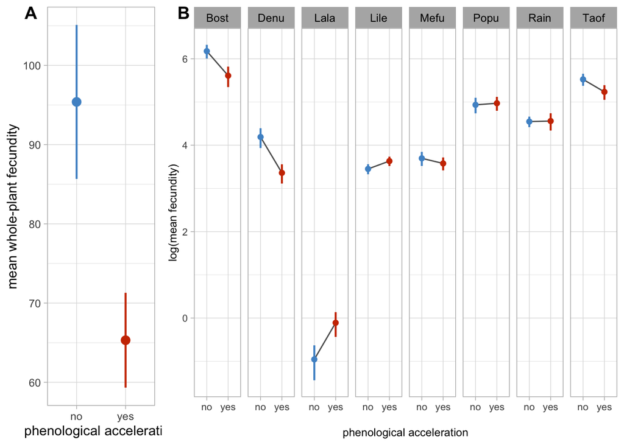

```r
combfecplot = ggarrange(phenfecplot, sppfecplotci,
          widths = c(1.75, 5),
          labels = c("A", "B"),
          # next two lines adjust label {"A", "B"} position
          hjust = c(-2, -1.25),
          vjust = 1.5,
          ncol = 2, nrow = 1,
          align = "v")

# display combined plot
combfecplot
```

```r
# # save plots (uncomment and run only when needed)
# ggsave(combfecplot, file = "plots/combined-fecundity-plots.jpg", width = 9, height = 4)
# ggsave(combfecplot, file = "plots/combined-fecundity-plots.pdf", width = 9, height = 4)

# cleanup
rm(sumsppfec, sppfecplot, sppfecplotci, phenfecplot, phenfecsum, combfecplot)
```

#### 3.2.3.4 plot interactive effects of phenology shift on fecundity

plot the data to visualize the results of the community fecundity models, which show significant three-way interactions between phenological change, number for flowers and species identity.

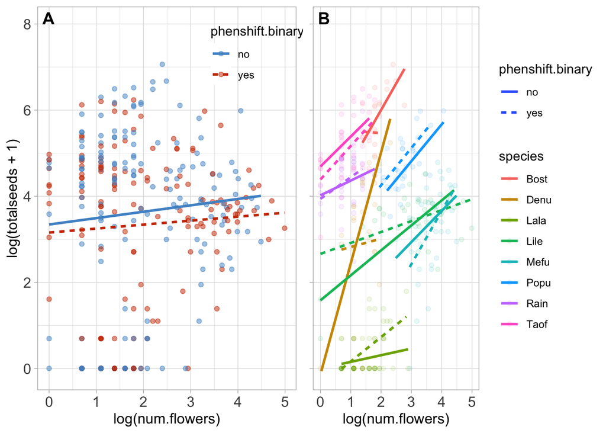

```r
# Plot fecundity by flower number, species aggregated:
plotcommunity1 = ggplot(commfecdat, aes(x=log(num.flowers), y=log(totalseeds+1),
                        color = phenshift.binary, linetype = phenshift.binary)) +
  geom_point(data = commfecdat, aes(group = species), size = 1.5, alpha = 0.5) +
  geom_smooth(method = 'lm', se = F) +
  theme_light() +
  ylim(-0.1, 8) +
  theme(axis.title.y = element_text(size = 12)) +
  theme(axis.title.x = element_text(size = 12)) +
  theme(axis.text = element_text(size = 12)) +
  theme(strip.text.x = element_text(size = 12, colour = "black")) +
  scale_colour_manual(values=c("steelblue3", "orangered3")) +
  theme(legend.position = c(0.85, 0.875)) +
  # theme(legend.background = element_rect(linetype="solid",
  #                                 colour ="grey36"))
  theme(legend.background = element_rect(fill = "transparent", colour = "transparent"))

# Plot fecundity by flower number, species separated by color:
plotcommunity2 = ggplot(commfecdat, aes(x=log(num.flowers), y=log(totalseeds+1),
                        color = species, linetype = phenshift.binary)) +
  geom_point(data = commfecdat, aes(group = species), size = 1.5, alpha = 0.1) +
  geom_smooth(method = 'lm', se = F) +
  theme_light() +
    ylim(-0.1, 8) +
  # theme(axis.title.y = element_text(size = 12)) +
  theme(axis.title.y = element_blank()) +
  theme(axis.title.x = element_text(size = 12)) +
  theme(axis.text = element_text(size = 12)) +
  theme(strip.text.x = element_text(size = 12, colour = "black")) +
  # get rid of y-axis labels, since they are the same as the other plot
  theme(axis.text.y = element_blank())

Fig3 = ggarrange(plotcommunity1, plotcommunity2,
          labels = c("A", "B"),
          # next two lines adjust label {"A", "B"} position
          hjust = c(-3.5, -1.25),
          vjust = 2,
          ncol = 2, nrow = 1,
          align = "v")

# display combined plot
Fig3
```

```r
# # SAVE PLOT
# # =============================
# # for now, the one without CIs
# # (keep this commented out to prevent repeated saving on GitHub)
# # re-save when this changes, but only as needed
# ggsave(plot = Fig3, width = 9, height = 4,
#         filename = "plots/community-fecundity-interactive.pdf")
# ggsave(plot = Fig3, width = 9, height = 4,
#         filename = "plots/community-fecundity-interactive.jpg")

# clean up
rm(Fig3, plotcommunity1, plotcommunity2)
```

Left panel (A) essentially shows the same thing as the aggregated plot, i.e. that phenological shifts overall reduce total fecundity; but shows it in interaction with flower number (agnostic to species identity)

Right panel (B) basically shows the same thing as the previous graph (though perhaps less clearly)—i.e. that different species respond differently to phenological acceleration.

## 3.3 Community-wide pollen limitation

This analysis is focused on whether or not pollen limitation was affected by phenological acceleration. To assess pollen limitation, we conducted hand-pollination experiments in many of the non-selfing species in our study. We can then compare the difference between hand-pollinated plants (which theoretically should not be pollen limited at all) and open plants (which could experience some pollen limitation). Specifically, this analysis informs us if some of the effects of our phenological acceleration experiments are due to pollen limitation vs. resource limitation.

### 3.3.1 data prep pollen limitation

- remove species for which hand pollination not conducted
- limit site-species combos to only those that have a phenological shift; that way we have the full-factorial data for each species in each site
  - this was taken care of in the data prep for community fecundity, but double-checked that was the case here

```r
# remove species for which hand pollination not conducted
nohand.spp = c("Bost", "Rain", "Taof")
pollimdat = reddat %>% filter(!(species %in% nohand.spp))
rm(nohand.spp) #cleanup

# relevel factors to not include missing levels
# some of this is probably redundant... oh well.
pollimdat$site = factor(pollimdat$site)
pollimdat$species = factor(pollimdat$species)
pollimdat$site.plot = factor(pollimdat$site.plot)
pollimdat$phenshift.binary = factor(pollimdat$phenshift.binary)
pollimdat$plant.treat = factor(pollimdat$plant.treat)
# `num.flowers` as integer
pollimdat$num.flowers = as.integer(pollimdat$num.flowers)

# limit site-species combos to only those that have
# a phenological shift; that would focus the data on only where we have the
# appropriate contrasts. also remove those with < 5 samples in a site

# Find these by comparing these tables (one for each species):
# table(pollimdat$site, pollimdat$phenshift.binary, pollimdat$species)
# table(pollimdat$phenshift.binary, pollimdat$species, pollimdat$site)

# for each species, we have at least 5 plant individuals that are phenologically
# accelerated and not; no further work to do.

# cleanup `reddat`--no longer used
rm(reddat)
```

### 3.3.2 models of community-wide pollen limitation

- follow general analysis plan for community-wide seed set; use only data from non-selfers
- include `plant.treat` (`open.hand` vs. `open`) as an interaction
  - main effect of `plant.treat` is relatively uninteresting—we expect hand pollination to increase fecundity at least in most species
- following analysis plan for community-wide seed set would yield a four-way interaction (phenological shift, hand pollination, species, number of flowers)
  - but… 4-way interactions are pretty intense / hard to interpret; a simpler 3-way interaction model that excludes flower number may also capture the dynamics; try both
  - if either the 3-way or the 4-way interaction is significant, that is consistent with differences in pollen limitation when plants are phenologically shifted vs. not
- to get at the **directionality** of pollen limitation, assess the 2-way interaction between `plant.treat` and `phenshift.binary`—that is, do we see differences between the overall seed production levels when hand pollinated vs. open (`plant.treat`) in phenologically advanced vs. non-advanced plants (`phenshift.binary`, i.e. our experimental phenology advancement)?
  - key to only include species that we experimentally hand-pollinated; sites where phenological acceleration occurred; and *specifically* site-species combos where we have the full-factorial combination of both phenologically advanced plants and not (control and experimentally accelerated plots within the same site), and which were hand pollinated and not

Finally, following initial model assessment with `DHARMa` we included a zero-inflation term since models without it show under-dispersion and marginally significant zero-inflation. By including zero-inflation in the model, the dispersion issues are resolved. See the next section (“model assessment”) for more info.

```r
# these models were tricky to specify syntactically... remember:
# - "*" specifies an interaction and both associated main effects
# - "/" specifies an interaction and main effect only on the left
# - ":" specifies the interaction without any main effects

# model with 2- and 3-way interactions (doesn't include flower number):
# adding in the `control` parameter to avoid "non-positive-definite Hessian"
# ("BFGS" optimizer):
# https://cran.r-project.org/web/packages/glmmTMB/vignettes/troubleshooting.html
poll.limit.mod = glmmTMB(totalseeds ~ (plant.treat:phenshift.binary)/species +
                  (1|site/site.plot), family = nbinom2, ziformula = ~1,
                  data = pollimdat, control=glmmTMBControl(optimizer=optim, optArgs=list(method="BFGS")))

# print results in Rmarkdown report
cat("\n model with 2- and 3-way interactions (doesn't include flower number)\n")
```

```
##
##  model with 2- and 3-way interactions (doesn't include flower number)
```

```r
Anova(poll.limit.mod)
```

```
## Analysis of Deviance Table (Type II Wald chisquare tests)
##
## Response: totalseeds
##                                       Chisq Df Pr(>Chisq)
## plant.treat:phenshift.binary         113.85  4  < 2.2e-16 ***
## plant.treat:phenshift.binary:species 994.29 16  < 2.2e-16 ***
## ---
## Signif. codes:  0 '***' 0.001 '**' 0.01 '*' 0.05 '.' 0.1 ' ' 1
```

```r
# model with 2- and 4-way interactions (includes flower number)
# tried the "BFGS" optimizer which was needed above;
# but here throws an error, so not using
poll.limit.mod24 = glmmTMB(totalseeds ~ (plant.treat:phenshift.binary)/(species:num.flowers) +
                        (1|site/site.plot), family = nbinom2, ziformula = ~1,
                        data = pollimdat)
# print results in Rmarkdown report
cat("\n model with 2- and 4-way interactions (includes flower number)\n")
```

```
##
##  model with 2- and 4-way interactions (includes flower number)
```

```r
Anova(poll.limit.mod24)
```

```
## Analysis of Deviance Table (Type II Wald chisquare tests)
##
## Response: totalseeds
##                                                    Chisq Df Pr(>Chisq)
## plant.treat:phenshift.binary                      11.686  4    0.01984 *
## plant.treat:phenshift.binary:species:num.flowers 506.648 20    < 2e-16 ***
## ---
## Signif. codes:  0 '***' 0.001 '**' 0.01 '*' 0.05 '.' 0.1 ' ' 1
```

```r
## use `broom.mixed` package to save model summary as a table
# first model (2- & 3- way interactions)
aov.poll.limit.mod = Anova(poll.limit.mod)
aov.poll.limit.mod = tidy(aov.poll.limit.mod)
write.csv(aov.poll.limit.mod, file = "results/community-pollen-limitation-model-results.csv")

# second model (2- & 4- way interactions)
aov.poll.limit.mod24 = Anova(poll.limit.mod24)
aov.poll.limit.mod24 = tidy(aov.poll.limit.mod24)
write.csv(aov.poll.limit.mod24, file = "results/community-pollen-limitation-model-results-2-4.csv")

# don't cleanup / remove models just yet, need to do assessment on them first
```

in a nutshell:

- 2-way interaction indicates a significant overall effect of pollen limitation and phenological advancement
  - plot (next code chunk) shows *greater* pollen limitation (i.e. more negative) under phenological advancement
- 3-way interaction highly significant: this indicates that pollen limitation is different when plants are phenologically shifted vs. not (taking into account plant species)
  - restated, this means that pollen limitation is different depending on whether or not plants were phenologically advanced in different plant species
  - plots are consistent with the idea that directionality of the effect is different depending on species
- 4-way interaction also highly significant:
  - this basically means the same thing as the 3-way, but also that phenological advancement affects pollen limitation “accumulation” with flower number differently in different species (also unsurprising)

#### 3.3.2.1 model assessment pollen limitation

Assess model residuals to see if the model meets basic statistical assumptions, using the `DHARMa` package. Also asssess dispersion (over- and under-dispersion) and zero-inflation. Trying this out for both models, those with 3-way and with 4-way interactions.

**model with 2- and 3- way interactions:**

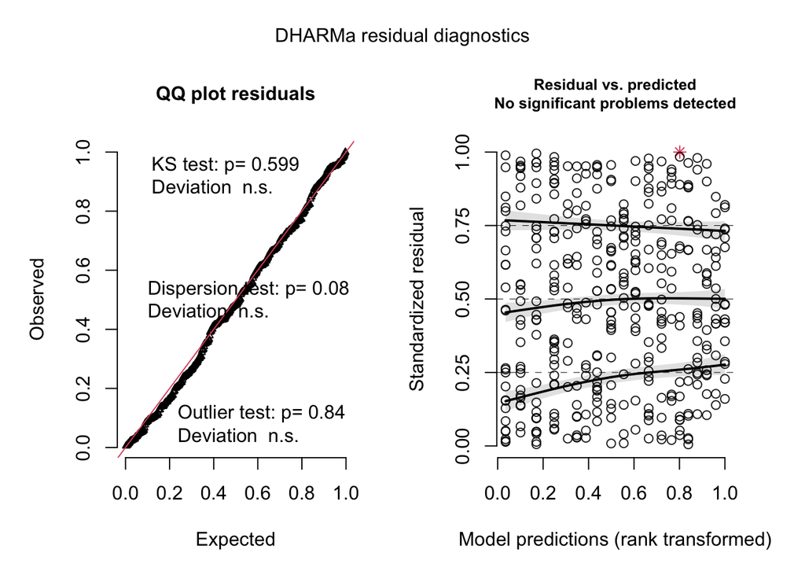

```r
# simulate residuals using DHARMa
# "simoutpollim" = simulation output, pollen limitation models
# (with 2- and 3-way interactions)
simoutpolllim <- simulateResiduals(fittedModel = poll.limit.mod, plot = F)
plot(simoutpolllim)
```

```r
# print dispersion and zero-inflation test results (don't plot for space)
testDispersion(simoutpolllim, plot = F)
```

```
##
##  DHARMa nonparametric dispersion test via sd of residuals fitted vs.
##  simulated
##
## data:  simulationOutput
## dispersion = 0.58741, p-value = 0.08
## alternative hypothesis: two.sided
```

```r
testZeroInflation(simoutpolllim, plot = F)
```

```
##
##  DHARMa zero-inflation test via comparison to expected zeros with
##  simulation under H0 = fitted model
##
## data:  simulationOutput
## ratioObsSim = 1.0714, p-value = 0.456
## alternative hypothesis: two.sided
```

Looks good! Carry on…

**model with 2- and 4- way interactions:**

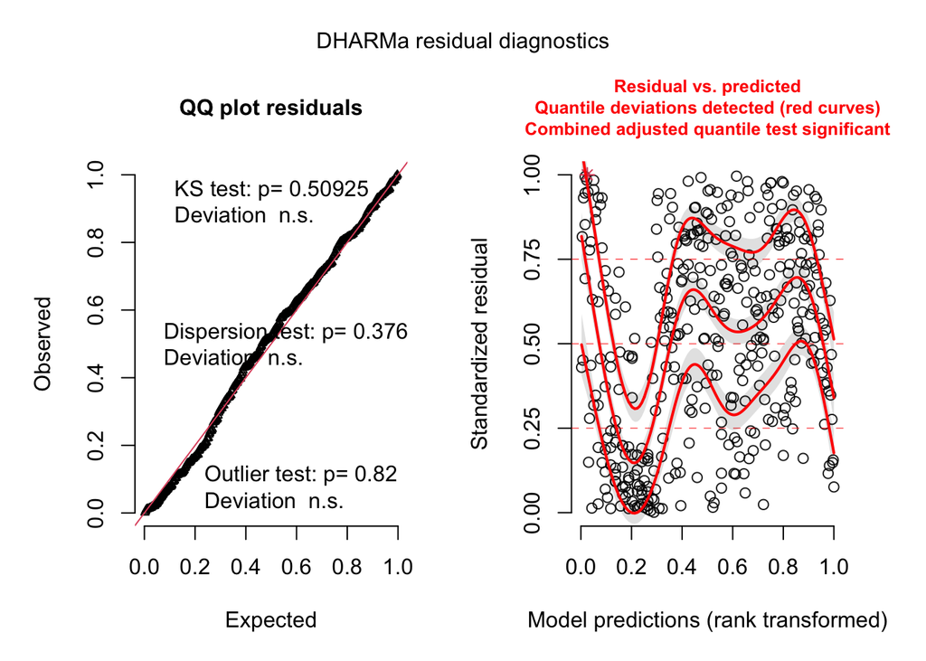

```r
# "simoutpollim24" = simulation output, pollen limitation models
# (with 2- and 4-way interactions)
simoutpolllim24 <- simulateResiduals(fittedModel = poll.limit.mod24, plot = F)
plot(simoutpolllim24)
```

```r
# print dispersion and zero-inflation test results (don't plot for space)
testDispersion(simoutpolllim24, plot = F)
```

```
##
##  DHARMa nonparametric dispersion test via sd of residuals fitted vs.
##  simulated
##
## data:  simulationOutput
## dispersion = 1.6169, p-value = 0.376
## alternative hypothesis: two.sided
```

```r
testZeroInflation(simoutpolllim24, plot = F)
```

```
##
##  DHARMa zero-inflation test via comparison to expected zeros with
##  simulation under H0 = fitted model
##
## data:  simulationOutput
## ratioObsSim = 1.154, p-value = 0.104
## alternative hypothesis: two.sided
```

```r
# cleanup
rm(simoutpolllim, simoutpolllim24, poll.limit.mod,
    poll.limit.mod24, aov.poll.limit.mod, aov.poll.limit.mod24)
```

looks problematic in terms of residuals vs. predicted values; probably best to stick to reporting the simpler model with 2- and 3-way interactions.

### 3.3.3 plots pollen limitation

#### 3.3.3.1 plot summarized community pollen limitation

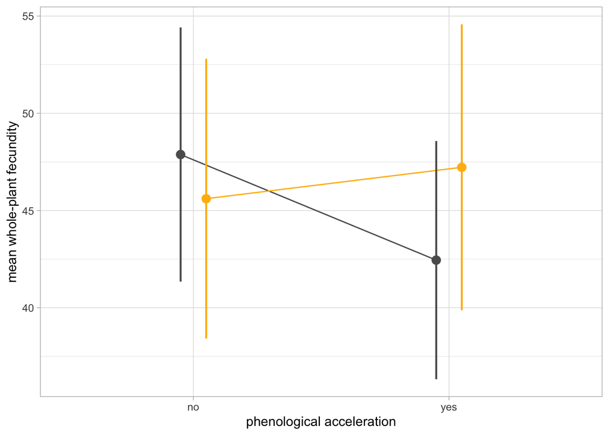

```r
pollimsum = pollimdat %>% group_by(phenshift.binary, plant.treat) %>%
  summarise(mean.seeds = mean(totalseeds), sd.seeds = sd(totalseeds, na.rm = T),
        n.plants = n()) %>%
        mutate(ci.lower = mean.seeds - 1.96*(sd.seeds/sqrt(n.plants)),
          ci.upper = mean.seeds + 1.96*(sd.seeds/sqrt(n.plants)),
          se.lower = mean.seeds - (sd.seeds/sqrt(n.plants)),
          se.upper = mean.seeds + (sd.seeds/sqrt(n.plants)))

pollimplot = ggplot(pollimsum, aes(x = phenshift.binary, y = mean.seeds,
                                   color = plant.treat)) +
  geom_point(aes(group = plant.treat),
             position = position_dodge(width=0.2), size = 3) +
  geom_line(aes(group = plant.treat), position = position_dodge(width=0.2)) +
  scale_colour_manual(values=c("gray36", "darkgoldenrod1")) +
  # # (to add CIs, un-comment the two lines below:)
  geom_linerange(aes(ymin = se.lower, ymax = se.upper),
                position = position_dodge(width=0.2), size = 0.75) +
  # scale_colour_manual(values=c("bisque4", "chartreuse2")) +
  xlab("phenological acceleration") +
  ylab("mean whole-plant fecundity") +
  theme_light() +
  theme(legend.position="none")

# display in Rmarkdown report
pollimplot
```

```r
# # SAVE PLOT
# # =============================
# # for now, the one without CIs
# # (keep this commented out to prevent repeated saving on GitHub)
# # re-save when this changes, but only as needed
# ggsave(plot = pollimplot, width = 4, height = 4,
#        filename = "plots/aggregated-pollen-limitation-plot.pdf")
# ggsave(plot = pollimplot, width = 4, height = 4,
#        filename = "plots/aggregated-pollen-limitation-plot.jpg")

# don't cleanup yet; need to combine plots below
```

Again, this plot suggests that experimental phenological acceleration increases pollen limitation, i.e. the difference between hand-pollinated (no pollen limitation) and open-pollinated (with possible pollen-limitation) is greater in plants with phenological acceleration relative to those without.

Somewhat surprising that open-pollinated plants produced on average more seeds in the open treatment when not phenologically advanced (left-hand points), but that difference may not be statistically meaningful. It is unsurprising that the error bars are large given site- and species-specific differences.

#### 3.3.3.2 plot by species pollen limitation

like the above plot, but split out by species

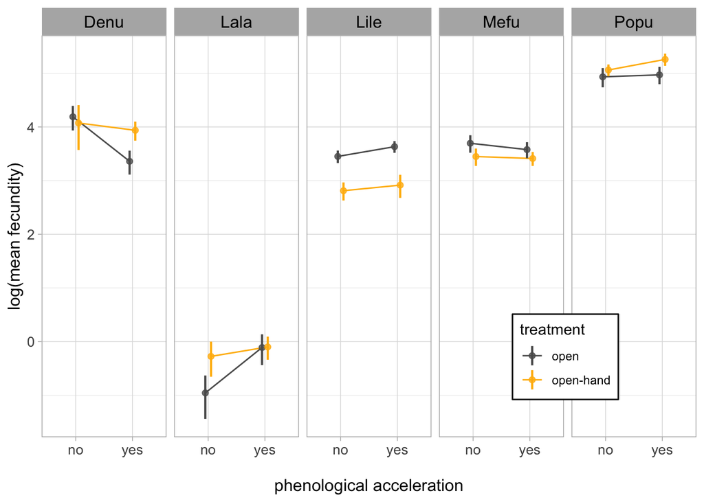

```r
# first, summarize the data
sumxpoll = pollimdat %>%
  group_by(species, phenshift.binary, plant.treat) %>%
  summarise(meanfecund = mean(totalseeds, na.rm = TRUE),
            sdfecund = sd(totalseeds, na.rm = TRUE),
            nfecund = n()) %>%
  mutate(sefecund = sdfecund / sqrt(nfecund),
         # here the `qt` argument is quartiles of the t-distribution;
         # this is more conservative than using a Gaussian / z-dist
         # e.g., in lowest sample size (14), quartile is 2.16 rather than 1.96
         lower.ci.fecund = meanfecund - qt(1 - (0.05 / 2), nfecund - 1) * sefecund,
         upper.ci.fecund = meanfecund + qt(1 - (0.05 / 2), nfecund - 1) * sefecund,
         lower.se.fecund = meanfecund - sefecund,
         upper.se.fecund = meanfecund + sefecund)

# plot without confidence intervals:
polllimplot = ggplot(sumxpoll, aes(x=phenshift.binary, y=log(meanfecund), color = plant.treat)) +
  geom_point(data = sumxpoll, size = 1.7, alpha = 0.8,
             position = position_dodge(width=0.2)) +
  geom_line(aes(group = plant.treat), position = position_dodge(width=0.2)) +
  facet_wrap(~species, nrow = 1) +
  ylab("log(mean fecundity)") +
  xlab("\nphenological shift (presence/absence)") +
  ggtitle("Planttreat:Phenshift:Species") +
  theme_light() +
  theme(axis.title.y = element_text(size = 12)) +
  theme(axis.title.x = element_text(size = 12)) +
  theme(axis.text = element_text(size = 10)) +
  theme(strip.text.x = element_text(size = 12, colour = "black")) +
  scale_colour_manual(values=c("gray36", "darkgoldenrod1"))

# # display plot
# # leave commented out for this version
# polllimplot

# plot with confidence intervals:
polllimplotci = ggplot(sumxpoll, aes(x=phenshift.binary, y=log(meanfecund),
                                     color = plant.treat)) +
  geom_line(aes(group = plant.treat), position = position_dodge(width=0.2)) +
  geom_linerange(aes(ymin=log(lower.se.fecund), ymax=log(upper.se.fecund)),
                size = 0.75, position = position_dodge(width=0.2)) +
  geom_point(data = sumxpoll, size = 1.7, alpha = 0.8,
             position = position_dodge(width=0.2)) +
  facet_wrap(~species, nrow = 1) +
  ylab("log(mean fecundity)") +
  xlab("\nphenological acceleration") +
  # ggtitle("Planttreat:Phenshift:Species, with CIs") +
  theme_light() +
  theme(axis.title.y = element_text(size = 12)) +
  theme(axis.title.x = element_text(size = 12)) +
  theme(axis.text = element_text(size = 10)) +
  theme(strip.text.x = element_text(size = 12, colour = "black")) +
  scale_colour_manual(values=c("gray36", "darkgoldenrod1")) +
  theme(legend.position = c(0.8, 0.2)) +
  theme(legend.background = element_rect(linetype="solid",
                                  colour ="black")) +
  labs(color = "treatment")

# display plot
polllimplotci
```

```r
# # SAVE PLOT
# # =============================
# # for now, the one without CIs
# # (keep this commented out to prevent repeated saving on GitHub)
# # re-save when this changes, but only as needed
# ggsave(plot = polllimplot, width = 6, height = 4,
#        filename = "plots/pollen-limitation-plot.pdf")
# ggsave(plot = polllimplot, width = 6, height = 4,
#        filename = "plots/pollen-limitation-plot.jpg")
```

#### 3.3.3.3 combine pollen limitation plots

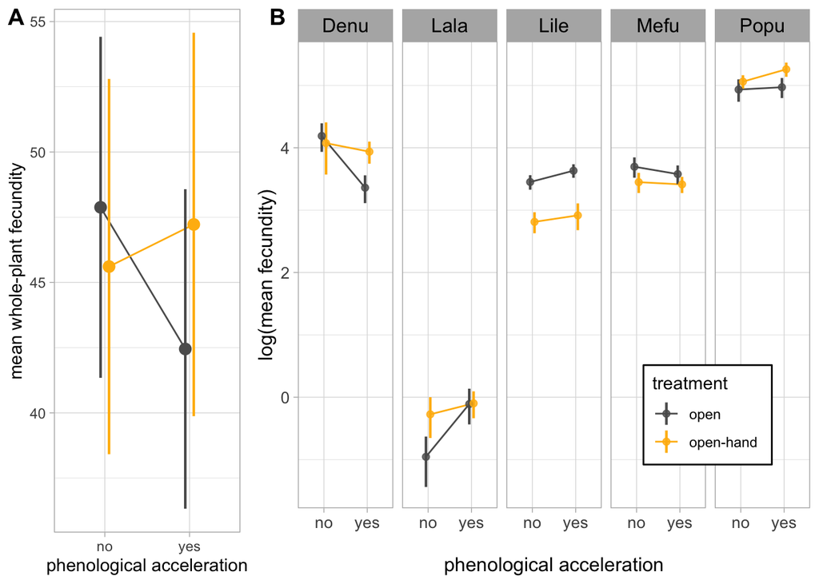

```r
combpollimplot = ggarrange(pollimplot, polllimplotci,
          widths = c(1.75, 4),
          labels = c("A", "B"),
          # next two lines adjust label {"A", "B"} position
          hjust = c(-0.5, -1.25),
          vjust = 1.5,
          ncol = 2, nrow = 1,
          align = "v")

# display combined plot
combpollimplot
```

```r
# # save plots (uncomment and run only when needed)
# ggsave(combpollimplot, file = "plots/combined-poll-lim-plots.jpg", width = 9, height = 4)
# ggsave(combpollimplot, file = "plots/combined-poll-lim-plots.pdf", width = 9, height = 4)

# cleanup
rm(sumxpoll, polllimplotci, pollimplot, polllimplot, combpollimplot, pollimsum)
```

## 3.4 Mixed conditional logit model (relative proportions of seed output)

Assessing whether the proportions of seed produced among different plants are different in control vs. manip, using the `mclogit` package:

> `mclogit` fits conditional logit models and mixed conditional logit models to count data and individual choice data, where the choice set may vary across choice occasions.

this is ideal because the “choice set”—set of plant species—is different in different sites.

`mclogit` uses an unusual data structure for the response variable:

> The left-hand side contains is expected to be a two-column matrix. The first column contains the choice counts or choice indicators (alternative is chosen=1, is not chosen=0). The second column contains unique numbers for each choice set. If individual-level data is used, choice sets correspond to the individuals, if aggregated data with choice counts are used, choice sets may e.g. correspond to covariate classes within clusters. The right-hand of the formula contains choice predictors. It should be noted that constants are deleted from the formula as are predictors that do not vary within choice sets.

We interpret this to mean that our data should have one row for each plant individual in each plot (two plots per site). The response variable should consist of 1) the seed counts (raw or standardized); and 2) an integer corresponding to each plant species.

We originally tried with data agreggated such that there is one row per species per plot, but this threw an error about “insufficient within-choice set varianceError” and also probably better to have more granularity in the data, given that we can specify random effects.

In these models, we want to use a slightly different dataset relative to those used in the community fecundity analyses. Here, we do *not* want to exclude site-species combinations for which there was no phenological advancement. The focal fixed effect is the snowmelt treatment, and the response is the proportion of seeds coming from the different plant species, so it is useful to the outcome if some species did not change their flowering time (i.e., phenological advancement) and others did. As before, we are not including the two sites for which the snowmelt acceleration did not change flowering phenology for any plant species.

In the data prep code chunk for the community fecundity models, we saved the data following the description above as `seedpropdat`, use that dataset here.

### 3.4.1 models seed proportion

```r
# model
seed.mclogit = suppressMessages(mclogit(cbind(totalseeds, as.integer(species))~plot.treat, random=~1|site, data = seedpropdat,
                                        dispersion = T))
```

```
## Iteration 1 - deviance = 49374.79 - criterion = 29.71217
## Iteration 2 - deviance = 49018.72 - criterion = 0.09662371
## Iteration 3 - deviance = 49018.18 - criterion = 0.0001527206
## Iteration 4 - deviance = 49018.18 - criterion = 5.702215e-10
```

```r
cat("Model summary, mixed conditional logit model:\n")
```

```
## Model summary, mixed conditional logit model:
```

```r
summary(seed.mclogit)
```

```
##
## Call:
## mclogit(formula = cbind(totalseeds, as.integer(species)) ~ plot.treat,
##     data = seedpropdat, random = ~1 | site, dispersion = T)
##
## Coefficents:
##                    Estimate Std. Error z value Pr(>|z|)
## plot.treatcontrol -0.180328   0.006814  -26.46   <2e-16 ***
## ---
## Signif. codes:  0 '***' 0.001 '**' 0.01 '*' 0.05 '.' 0.1 ' ' 1
##
## (Co-)Variances:
## Grouping level: site
##             Estimate   Std.Err.
## (Intercept) 0.04595    5.605e-05
##
## Null Deviance:     52530
## Residual Deviance: 49020
## Number of Fisher Scoring iterations:  4
## Number of observations
##   Groups by site: 6
##   Individual observations:  86453
```

```r
rm(site.list, seed.mclogit) # cleanup
```

The model shows a highly significant difference in counts / proportions of seed in control vs. snowmelt acceleration plots. The take-home message is that snowmelt acceleration changes proportions of seed in different plant species, i.e. alters seed production differentially across the plant community.

Unfortunately, we are not aware of any methods for model assessment for `mclogit` models; in particular their output does not work as input to the `DHARMa` package.

Note that in the model specification, we set `dispersion = T` such that the model includes an estimate of the dispersion parameter, and thus overdispersion should not be an issue.

### 3.4.2 plot seed proportion

start by summarizing seed data by site, plot treatment (snowmelt acceleration vs. control), and species

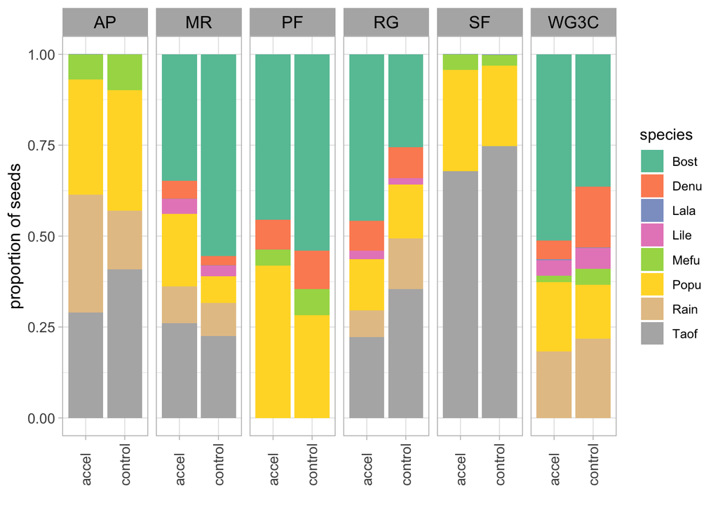

```r
# summarize data
propdat <- seedpropdat %>% group_by(site, site.abbrev, plot.treat,
              species) %>%
          summarise(n.plants=n(), mean.seed=mean(totalseeds),
              sd.seed=sd(totalseeds))

# getting a decent color palette is tough for these
# using `scale_fill_brewer(palette = "Set2")`;
# initially used "Set3" but described as "clown vomit"

propseed = ggplot(propdat, aes(fill=species, y=mean.seed, x=plot.treat)) +
    geom_bar(position="fill", stat="identity") + facet_grid(~ site.abbrev) +
    theme_light() +
    scale_fill_brewer(palette = "Set2") +
   xlab("") + ylab("proportion of seeds") +
  theme(axis.title.y = element_text(size = 12)) +
    theme(axis.text.y = element_text(size = 10)) +
  theme(axis.text.x = element_text(size = 10, angle = 90, vjust = 0.5, hjust = 0)) +
  theme(strip.text.x = element_text(size = 12, colour = "black"))

# display plot
propseed
```

```r
# # SAVE PLOT
# # =============================
# # (keep this commented out to prevent repeated saving on GitHub)
# # re-save when this changes, but only as needed
# ggsave(plot = propseed, width = 6, height = 4,
#        filename = "plots/seed-proportion-plot.pdf")
# ggsave(plot = propseed, width = 6, height = 4,
#        filename = "plots/seed-proportion-plot.jpg")

# cleanup
rm(propseed, propdat)
```